# Qualitative Human Activity Recognition

Aravind Sesetty

Friday, February 20, 2015

## Abstract

People regularly quantify how much of a particular activity they do, but they rarely quantify how well they do it. In this project, we will examin data from accelerometers on the belt, forearm, arm, and dumbell of 6 participants. Participants were asked to perform one set of 10 repetitions of the Unilateral Dumbbell Biceps Curl in 5 different ways:

- **Class A**: Exactly according to the specification
- **Class B**: Throwing the elbows to the front
- **Class C**: Lifting the dumbbell only halfway
- **Class D**: Lowering the dumbbell only halfway
- **Class E**: Throwing the hips to the front

Class A corresponds to the specified execution of the exercise, while the other 4 classes B, C, D, E correspond to common mistakes.

Our results underline the potential of model-based prediction and also predict the manner in which they did the exercise.

## Data

The data for this project come from Groupware@LES - Human Activity Recognition Project

- Training Data
- Test Data

Download both Training & Test Data and read the `*.csv` files into R

```r
setwd("C:/RDev/workdir/PML")
download.file("http://d396qusza40orc.cloudfront.net/predmachlearn/pml-training.csv", "pml-training.csv", mode = "wb")
download.file("http://d396qusza40orc.cloudfront.net/predmachlearn/pml-testing.csv", "pml-testing.csv", mode = "wb")

trainingSet <- read.csv("pml-training.csv", header=TRUE, na.strings=c("","NA","#DIV/0!"))
testingSet <- read.csv("pml-testing.csv", header=TRUE, na.strings=c("","NA","#DIV/0!"))

dim(trainingSet)
```

```
## [1] 19622   160
```

```r
dim(testingSet)
```

```
## [1]  20 160
```

## Pre-Processing

**1. Maunal Selection and Removal of columns**

- X: Not part of observations
- user_name: Prediction is not going to be per subject
- raw_timestamp_part_1: Prediction is not going to be based on time
- raw_timestamp_part_2: Prediction is not going to be based on time
- cvtd_timestamp: Prediction is not going to be based on time
- new_window: Prediction has no impact of window
- num_window: Prediction has no impact of window

```r
trainingSet <- trainingSet[,-c(1:7)]
testingSet <- testingSet[,-c(1:7)]
```

**2. Near Zero-Variance Predictors**

- Search for predictors that take an unique value across samples and remove them.
- This kind of predictors are not only non-informative but can also break some models.

```r
nzv <- nearZeroVar(trainingSet)
trainingSet <- trainingSet[, -nzv]

#nzv <- nearZeroVar(testingSet)
#testingSet <- testingSet[, -nzv]
```

**3. Removing columns based on no. of NAs**

- Remove columns in which the NA values are more than 90% threshold value.

```r
naPerColumn <- apply(trainingSet, 2, function(trainingSetCol) {sum(is.na(trainingSetCol))})
trainingSet <- trainingSet[, -which(naPerColumn > nrow(trainingSet)*0.9 )]

naPerColumn <- apply(testingSet, 2, function(testingSetCol) {sum(is.na(testingSetCol))})
testingSet <- testingSet[, -which(naPerColumn > nrow(testingSet)*0.9 )]

dim(trainingSet)
```

```
## [1] 19622    53
```

```r
dim(testingSet)
```

```
## [1] 20 53
```

## Data Splitting

Split the Training Set into two subsets (60% : 40%), one for training the model and the other for cross-validation.

```r
trainingSetIndex <- createDataPartition(y=trainingSet$classe, p=0.60, list=FALSE)

trainingSubSet <- trainingSet[trainingSetIndex,]
testingSubSet <- trainingSet[-trainingSetIndex,]
```

## Plotting Predictors

Show the densities of all Classes A, B, C, D, E through Density Plot.

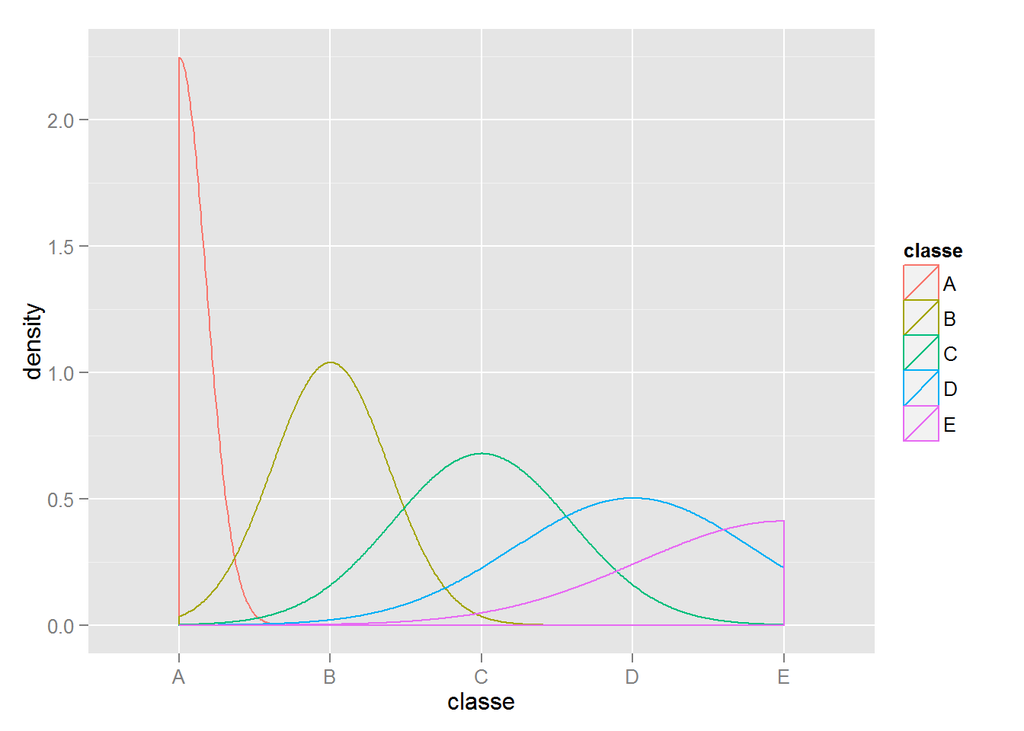

```r
classePlot <- qplot(classe, colour=classe, data=trainingSubSet, geom="density")
print(classePlot)
```

## Fit a Model

#### 1. CART Model

- Use **CART Model** to train the model on training subset
- Use the trained **CART Model** to predict on test subset
- Generate the **confusionMatrix** for “Overall Statistics”" and “Statistics by Class”"

```r
modelFitCART <- train(classe ~ ., method="rpart", data=trainingSubSet)
predictions <- predict(modelFitCART, newdata=testingSubSet)
confusionMatrix(predictions, testingSubSet$classe)
```

```
## Confusion Matrix and Statistics
##
##           Reference
## Prediction    A    B    C    D    E
##          A 2025  626  645  570  204
##          B   35  504   45  225  187
##          C  167  388  678  491  408
##          D    0    0    0    0    0
##          E    5    0    0    0  643
##
## Overall Statistics
##
##                Accuracy : 0.491
##                  95% CI : (0.48, 0.502)
##     No Information Rate : 0.284
##     P-Value [Acc > NIR] : <2e-16
##
##                   Kappa : 0.335
##  Mcnemar's Test P-Value : NA
##
## Statistics by Class:
##
##                      Class: A Class: B Class: C Class: D Class: E
## Sensitivity             0.907   0.3320   0.4956    0.000   0.4459
## Specificity             0.636   0.9223   0.7755    1.000   0.9992
## Pos Pred Value          0.498   0.5060   0.3180      NaN   0.9923
## Neg Pred Value          0.945   0.8520   0.8792    0.836   0.8890
## Prevalence              0.284   0.1935   0.1744    0.164   0.1838
## Detection Rate          0.258   0.0642   0.0864    0.000   0.0820
## Detection Prevalence    0.519   0.1269   0.2717    0.000   0.0826
## Balanced Accuracy       0.771   0.6271   0.6356    0.500   0.7226
```

#### 2. Random Forest Model

- Use **Random Forest Model** to train the model on training subset
- Use the trained **Random Forest Model** to predict on test subset
- Generate the **confusionMatrix** for “Overall Statistics”" and “Statistics by Class”"

```r
modelFitRF <- randomForest(classe ~ ., data=trainingSubSet, importance=FALSE)
predictions <- predict(modelFitRF, newdata=testingSubSet)
confusionMatrix(predictions, testingSubSet$classe)
```

```
## Confusion Matrix and Statistics
##
##           Reference
## Prediction    A    B    C    D    E
##          A 2232    4    0    0    0
##          B    0 1513    9    0    0
##          C    0    1 1359   17    0
##          D    0    0    0 1267    5
##          E    0    0    0    2 1437
##
## Overall Statistics
##
##                Accuracy : 0.995
##                  95% CI : (0.993, 0.997)
##     No Information Rate : 0.284
##     P-Value [Acc > NIR] : <2e-16
##
##                   Kappa : 0.994
##  Mcnemar's Test P-Value : NA
##
## Statistics by Class:
##
##                      Class: A Class: B Class: C Class: D Class: E
## Sensitivity             1.000    0.997    0.993    0.985    0.997
## Specificity             0.999    0.999    0.997    0.999    1.000
## Pos Pred Value          0.998    0.994    0.987    0.996    0.999
## Neg Pred Value          1.000    0.999    0.999    0.997    0.999
## Prevalence              0.284    0.193    0.174    0.164    0.184
## Detection Rate          0.284    0.193    0.173    0.161    0.183
## Detection Prevalence    0.285    0.194    0.176    0.162    0.183
## Balanced Accuracy       1.000    0.998    0.995    0.992    0.998
```

## Evaluation

Predict the Test Data by applying the selected RandomForest model

```r
predictions <- predict(modelFitRF, newdata=testingSet)
print(predictions)
```

```
##  1  2  3  4  5  6  7  8  9 10 11 12 13 14 15 16 17 18 19 20
##  B  A  B  A  A  E  D  B  A  A  B  C  B  A  E  E  A  B  B  B
## Levels: A B C D E
```

```r
testingSet$classe <- cbind(as.character(predictions))
testingSet$classe <- as.factor(testingSet$classe)
confusionMatrix(predictions, testingSet$classe)
```

```
## Confusion Matrix and Statistics
##
##           Reference
## Prediction A B C D E
##          A 7 0 0 0 0
##          B 0 8 0 0 0
##          C 0 0 1 0 0
##          D 0 0 0 1 0
##          E 0 0 0 0 3
##
## Overall Statistics
##
##                Accuracy : 1
##                  95% CI : (0.832, 1)
##     No Information Rate : 0.4
##     P-Value [Acc > NIR] : 1.1e-08
##
##                   Kappa : 1
##  Mcnemar's Test P-Value : NA
##
## Statistics by Class:
##
##                      Class: A Class: B Class: C Class: D Class: E
## Sensitivity              1.00      1.0     1.00     1.00     1.00
## Specificity              1.00      1.0     1.00     1.00     1.00
## Pos Pred Value           1.00      1.0     1.00     1.00     1.00
## Neg Pred Value           1.00      1.0     1.00     1.00     1.00
## Prevalence               0.35      0.4     0.05     0.05     0.15
## Detection Rate           0.35      0.4     0.05     0.05     0.15
## Detection Prevalence     0.35      0.4     0.05     0.05     0.15
## Balanced Accuracy        1.00      1.0     1.00     1.00     1.00
```